# CombinedDataset For Sepsis Prediction

Take this notebook as a continuation of the MAINnotebook

Please keep in mind that i did go through a lot of back and forward between my C# code, DataGrip and This Notebook. This is an Experiment and this notebook shows only vague walkthrough of the main steps i took .( i will be not going in dept on steps already explained in the previous notebooks)

```python
import sklearn
import pandas
import seaborn
import numpy as np

from sklearn.preprocessing import StandardScaler
from sklearn import preprocessing
from sklearn.svm import SVC
from sklearn.metrics import accuracy_score, confusion_matrix
```

## The Combination Process

the dataset i am adding to my existing one:

- contains 40336 patients and contains different test results and Vital signs for each hour after admission, a patient becomes labeled as positive only in the hour he was diagnosed with sepsis , some test results are only taken periodically so it is full of Null values .
- there are a few common columns between the two datasets : Plasma Glucose, Bloud Presure, and Age
  - the Bloud Presure in this dataset is split into 3 difrent values : Systolic, Diastolic, and Mean Arterial Pressure we will be taking the average.
- we will be taking the average values over the whole period of admition for negative patients, and for positive patients we will be taking the average only after the patient was diagnosed with sepsis. This way we insure ourselves we won`t be missing a peek value.

## The Dataset I am going to be adding

unfortunatly we have 0 insight on where the data is coming from. Source: https://www.kaggle.com/datasets/salikhussaini49/prediction-of-sepsis

but since we are only going to be using it as aditional data to our existing dataSet it can only add more veriaty, if we were to use it as a standalone dataset it woud be a no go (more detail on what we requre from our data in the Data Reliability section of the Main notebook)

```python
newDataset_df = pandas.read_csv("newSourceSepsisDataset.csv" )
newDataset_df.sample(10)
```

|  | ID | Hour | HR | O2Sat | Temp | SBP | MAP | DBP | Resp | EtCO2 | ... | Fibrinogen | Platelets | Age | Gender | Unit1 | Unit2 | HospAdmTime | ICULOS | SepsisLabel | Patient_ID |
| --- | --- | --- | --- | --- | --- | --- | --- | --- | --- | --- | --- | --- | --- | --- | --- | --- | --- | --- | --- | --- | --- |
| 681136 | 18 | 18 | 60.0 | 95.0 | NaN | 141.0 | 91.00 | 65.0 | 15.0 | NaN | ... | NaN | NaN | 81.87 | 1 | 0.0 | 1.0 | -0.01 | 19 | 0 | 12106 |
| 626567 | 5 | 5 | 105.0 | 97.0 | 37.28 | 153.0 | 87.67 | NaN | 16.0 | NaN | ... | NaN | 73.0 | 77.61 | 0 | 1.0 | 0.0 | -35.95 | 6 | 0 | 13025 |
| 805829 | 49 | 49 | 108.0 | 98.0 | NaN | 94.0 | 67.00 | 58.0 | 20.0 | NaN | ... | NaN | NaN | 59.00 | 1 | 1.0 | 0.0 | -0.01 | 50 | 0 | 102427 |
| 939561 | 2 | 2 | 115.0 | 100.0 | NaN | 143.0 | 104.00 | 94.0 | 17.0 | NaN | ... | NaN | NaN | 20.00 | 0 | 1.0 | 0.0 | -142.89 | 3 | 0 | 113635 |
| 751573 | 9 | 9 | 71.0 | 95.0 | 37.00 | 100.0 | 65.33 | NaN | 18.0 | NaN | ... | NaN | NaN | 46.43 | 0 | NaN | NaN | -116.55 | 10 | 0 | 8697 |
| 1128714 | 6 | 6 | 96.0 | 100.0 | NaN | 111.0 | 80.00 | 64.0 | NaN | NaN | ... | NaN | NaN | 25.00 | 1 | 1.0 | 0.0 | -768.56 | 7 | 0 | 107633 |
| 634440 | 18 | 18 | 87.0 | 98.0 | NaN | 143.0 | 75.00 | NaN | 19.0 | NaN | ... | NaN | NaN | 81.81 | 0 | 1.0 | 0.0 | -0.02 | 20 | 0 | 12869 |
| 1390960 | 29 | 29 | 68.0 | 96.0 | 37.00 | 110.0 | 72.00 | 61.0 | 17.0 | NaN | ... | NaN | NaN | 62.00 | 1 | 1.0 | 0.0 | -5.52 | 30 | 0 | 103933 |
| 78432 | 15 | 15 | 113.0 | 92.0 | 38.83 | 162.0 | 90.67 | NaN | 17.0 | NaN | ... | NaN | NaN | 61.87 | 0 | 1.0 | 0.0 | -0.02 | 16 | 0 | 12169 |
| 957585 | 34 | 34 | 84.0 | 94.0 | NaN | 123.0 | 87.00 | 62.0 | 18.0 | NaN | ... | NaN | NaN | 49.00 | 0 | NaN | NaN | -51.38 | 35 | 0 | 107164 |

10 rows × 44 columns

## How i combined the dataset in .NET

1. imported the 2 datasets in
2. crating apropariete DTOs for the SourceCSV, AdditionCSV, and the CombinedCSV
- i decided to do the required custom calculations while transforming the type insted of using a model mapper

```
public OutputCsvRowDTO(AdditionCsvRowDTO additionCsvRowDTO)
    {
        Sepssis = Convert.ToInt32(additionCsvRowDTO.SepsisLabel);
        ID = additionCsvRowDTO.ID;
        Age = Convert.ToInt32(additionCsvRowDTO.Age);
        PRG = (int)ScaleGlucose(Convert.ToInt32(additionCsvRowDTO.Glucose), 9, 999, 0, 9);
        var bpARR = new double?[] { Convert.ToDouble(additionCsvRowDTO.SBP), Convert.ToDouble(additionCsvRowDTO.MAP), Convert.ToDouble(additionCsvRowDTO.DBP) };
        PR = (int)bpARR.Average();
        //the rest of the fields
```

4. Transforming the data
- calculating avgResultofPostiveSepsisPatientsInLateStage

```
List<AdditionCsvRowDTO> avgResultofPostiveSepsisPatientsInLateStage = _additionCsvRowDtos
            .Where(x => x.SepsisLabel == "1").GroupBy(x => x.Patient_ID).Select(x => new AdditionCsvRowDTO
            {
                 ID = x.First().Patient_ID,
                        HR = x.Average(y => y.HR),
                        O2Sat = x.Average(y => y.O2Sat),
                        //the rest of the fields (for some value ofcourse we dont get the avarage like Age, Gender ...)
```

- calculating avgResultofNegativeSepsisPatientsInLateStage

since i am going to be taking a multi threaded aproach beacuase iterating over the collection is unavoidable in this case (ultra slow) (we cant use LINQ which only goes over memory refresher addresses to find an object: IndexOF(lambda expresion) and also ofcourse uses SPANS which i am not going to ) we need to define a couple of help refrence Colections which are multi thread safe to avoid using a lock statement (locking acess to execution of only one thread)

```
List<AdditionCsvRowDTO> tmpListWithAllRowsWhereSepsisIsNegative =
            _additionCsvRowDtos.Where(x => x.SepsisLabel == "0").ToList();
        ConcurrentBag<string> avgResultOfNegativePatientsPatientIDS = new();
        ConcurrentBag<AdditionCsvRowDTO> avgResultOfNegativePatients = new();
        List<string> positiveSepsisPatientIds = avgResultofPostiveSepsisPatientsInLateStage
            .Select(x => x.Patient_ID)
            .ToList();
```

```
Parallel.ForEach(tmpListWithAllRowsWhereSepsisIsNegative.AsParallel().AsOrdered(), (row, state) =>
        {

            if ( positiveSepsisPatientIds.Contains(row.Patient_ID) || avgResultOfNegativePatientsPatientIDS.Contains(row.Patient_ID))
            {
                return;
            }
            else
            {

                avgResultOfNegativePatientsPatientIDS.Add(row.Patient_ID);
                avgResultOfNegativePatients.Add(_additionCsvRowDtos.Where(x => x.Patient_ID == row.Patient_ID)
                    .GroupBy(x => x.Patient_ID).Select(x => new AdditionCsvRowDTO
                    {
                        ID = x.First().Patient_ID,
                        HR = x.Average(y => y.HR),
                        O2Sat = x.Average(y => y.O2Sat),
                        //the rest of the fields
                        //and ofcourse we  .First() to put only one record in the Bag
```

5. creating the output Object collection

```
outputCsvRowDtos.AddRange( _sourceCsvRowDtos.Select(x => new OutputCsvRowDTO(x)).ToList());
        outputCsvRowDtos.AddRange(avgResultofPostiveSepsisPatientsInLateStage.Select(x => new OutputCsvRowDTO(x))
            .ToList());
        outputCsvRowDtos.AddRange(avgResultOfNegativePatients.Select(x => new OutputCsvRowDTO(x)).ToList());
```

6. writing the output to a csv file

```
File.WriteAllText(outputCSVpath, Output.ToCsv());
```

7. Importing the resulting DataSet in DataGrip to evaluate and check for any mistakes in the prosess (which there were :) and going back to the code to fix it)
8. Balancing the Dataset in SQLITE

```
DELETE FROM "OUTPUT"  WHERE ID IN (
    SELECT ID FROM "OUTPUT"  WHERE Sepssis = 0 ORDER BY RANDOM() LIMIT 6505
)
```

## Crating the new Model

1. Taking a Look at the new CombinedDataset
2. Loking for new feature candidates

```python
columns = ["ID", "PRG", "PL", "PR", "SK", "TS", "M11", "BD2", "Age","Insurance", "HR","O2Sat","Temp","Resp","EtCO2","BaseExcess","HCO3","FiO2","pH","PaCO2","SaO2","AST","BUN","Alkalinephos","Calcium","Chloride","Creatinine","Bilirubin_direct","Lactate","Magnesium","Phosphate","Potassium","Bilirubin_total","TroponinI","Hct","Hgb","PTT","WBC","Fibrinogen","Platelets","Gender", "Sepssis"]
df = pandas.read_csv("balancedCombinedDataset.csv" , names=columns)
df.sample(10)
```

|  | ID | PRG | PL | PR | SK | TS | M11 | BD2 | Age | Insurance | ... | Bilirubin_total | TroponinI | Hct | Hgb | PTT | WBC | Fibrinogen | Platelets | Gender | Sepssis |
| --- | --- | --- | --- | --- | --- | --- | --- | --- | --- | --- | --- | --- | --- | --- | --- | --- | --- | --- | --- | --- | --- |
| 1371 | 913 | 1 | 0 | 82 | 0 | 0 | NaN | NaN | 70 | 0 | ... | NaN | NaN | 25.40 | 9.000000 | 28.300000 | 11.000000 | NaN | 132.000000 | 1.0 | 0 |
| 566 | 11317 | 0 | 0 | 82 | 0 | 0 | NaN | NaN | 53 | 0 | ... | NaN | NaN | 36.30 | NaN | NaN | NaN | NaN | 261.000000 | 1.0 | 1 |
| 433 | 8399 | 1 | 0 | 26 | 0 | 0 | NaN | NaN | 69 | 0 | ... | NaN | NaN | 25.80 | 9.500000 | 50.800000 | 10.600000 | NaN | 181.000000 | 0.0 | 1 |
| 1617 | 7316 | 1 | 0 | 75 | 0 | 0 | NaN | NaN | 72 | 0 | ... | 0.40 | NaN | 34.55 | 10.300000 | NaN | 9.350000 | NaN | 122.000000 | 0.0 | 0 |
| 596 | 616 | 0 | 0 | 69 | 0 | 0 | NaN | NaN | 88 | 0 | ... | NaN | NaN | NaN | NaN | NaN | NaN | NaN | NaN | 1.0 | 1 |
| 1080 | 13161 | 1 | 0 | 97 | 0 | 0 | NaN | NaN | 52 | 0 | ... | 7.98 | NaN | 28.66 | 10.640000 | 34.160000 | 5.340000 | NaN | 84.200000 | 1.0 | 0 |
| 1696 | 10683 | 1 | 0 | 78 | 0 | 0 | NaN | NaN | 66 | 0 | ... | NaN | NaN | 36.50 | 12.150000 | 32.900000 | 19.450000 | NaN | 165.500000 | 1.0 | 0 |
| 1481 | 10184 | 1 | 0 | 86 | 0 | 0 | NaN | NaN | 69 | 0 | ... | NaN | NaN | 32.58 | 10.857143 | 51.433333 | 9.133333 | NaN | 199.666667 | 1.0 | 0 |
| 693 | 13054 | 0 | 0 | 57 | 0 | 0 | NaN | NaN | 88 | 0 | ... | NaN | NaN | 30.80 | 10.200000 | 34.900000 | 11.600000 | NaN | 227.000000 | 0.0 | 1 |
| 635 | 4376 | 1 | 0 | 91 | 0 | 0 | NaN | NaN | 77 | 0 | ... | 1.60 | NaN | 32.70 | 10.900000 | NaN | 8.500000 | NaN | 257.000000 | 1.0 | 1 |

10 rows × 42 columns

```python
group_info = df.groupby(["Sepssis"])["Sepssis"].count()
group_info
```

```
Sepssis
0    881
1    881
Name: Sepssis, dtype: int64
```

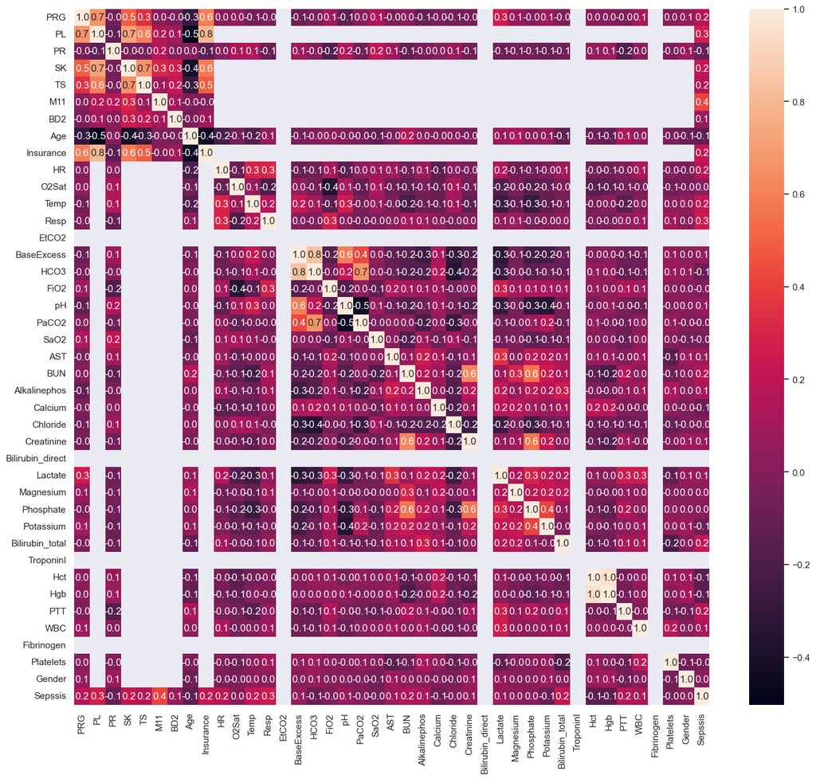

```python
import matplotlib.pyplot as plt
fig, ax = plt.subplots(figsize=(17, 15))
corr = df.corr(numeric_only=True)
plot = seaborn.heatmap(corr, cbar=True, annot=True, fmt=".1f", ax=ax)
```

### Explenation

after looking at the HeatMap we can safely remove EtCO2 , Bilirubin_direct, TroponinI, Fibrinogen since they don't contain any data

let`s dive deeper into the domain understanding and reasone the high corelation values:

o2Sat vs FiO2 (Fraction of inspired oxygen (%)) - 0.4 this is a corelation between how much oxygen a person inhales and how much it ends up in the blood

hcO3 (Bicarbonate (mmol/L)) vs PaCO2 (Partial pressure of carbon dioxide from arterial blood (mm Hg)) - 0.7 This is because carbon dioxide reacts with water to form bicarbonate ions in the blood, and therefore an increase in PaCO2 will result in an increase in the concentration of bicarbonate ions.

BaseEcess (Measure of excess bicarbonate (mmol/L)) vs hco3 (Bicarbonate (mmol/L)) -0.8 This is expected, as base excess is a measure of the amount of excess bicarbonate in the blood

Ph (N/A) vs PaCo2 (Partial pressure of carbon dioxide from arterial blood (mm Hg)) - 0.5 The dataset didnt provide information of what the Ph is mesured, that doesnt meen to ignore the unlabled data

Phosphate vs BUN (Blood urea nitrogen (mg/dL)) - 0.6 Phosphate and urea nitrogen are both waste products of metabolism that are excreted by the kidneys

#### Scaling and Preparation for Feature Selection

```python
from sklearn.preprocessing import StandardScaler, MinMaxScaler

df.drop(columns=["ID"], inplace=True)
from sklearn import preprocessing
encoder = preprocessing.LabelEncoder()
df["Sepssis"] = encoder.fit_transform(df["Sepssis"])

# Separate the target variable from the input features
X = df.iloc[:,:-1]  # input features
y = df.iloc[:, -1]  # target variable (sepsis)

# Scale the input features only\
#scaler = StandardScaler()
scaler = MinMaxScaler(feature_range=(0, 1))
scaler.fit(X)
X_scaled = scaler.transform(X)

# Combine the scaled input features and the target variable
df_scaled = pandas.concat([pandas.DataFrame(X_scaled, columns=X.columns), y], axis=1)
df_scaled.head()
```

|  | PRG | PL | PR | SK | TS | M11 | BD2 | Age | Insurance | HR | ... | Bilirubin_total | TroponinI | Hct | Hgb | PTT | WBC | Fibrinogen | Platelets | Gender | Sepssis |
| --- | --- | --- | --- | --- | --- | --- | --- | --- | --- | --- | --- | --- | --- | --- | --- | --- | --- | --- | --- | --- | --- |
| 0 | 0.352941 | 0.747475 | 0.553846 | 0.353535 | 0.000000 | 0.500745 | 0.231132 | 0.450704 | 0.0 | NaN | ... | NaN | NaN | NaN | NaN | NaN | NaN | NaN | NaN | NaN | 1 |
| 1 | 0.058824 | 0.429293 | 0.507692 | 0.292929 | 0.000000 | 0.396423 | 0.112779 | 0.183099 | 0.0 | NaN | ... | NaN | NaN | NaN | NaN | NaN | NaN | NaN | NaN | NaN | 0 |
| 2 | 0.470588 | 0.924242 | 0.492308 | 0.000000 | 0.000000 | 0.347243 | 0.250429 | 0.197183 | 1.0 | NaN | ... | NaN | NaN | NaN | NaN | NaN | NaN | NaN | NaN | NaN | 1 |
| 3 | 0.000000 | 0.691919 | 0.307692 | 0.353535 | 0.198582 | 0.642325 | 0.943396 | 0.211268 | 1.0 | NaN | ... | NaN | NaN | NaN | NaN | NaN | NaN | NaN | NaN | NaN | 1 |
| 4 | 0.294118 | 0.585859 | 0.569231 | 0.000000 | 0.000000 | 0.381520 | 0.048456 | 0.169014 | 1.0 | NaN | ... | NaN | NaN | NaN | NaN | NaN | NaN | NaN | NaN | NaN | 0 |

5 rows × 41 columns

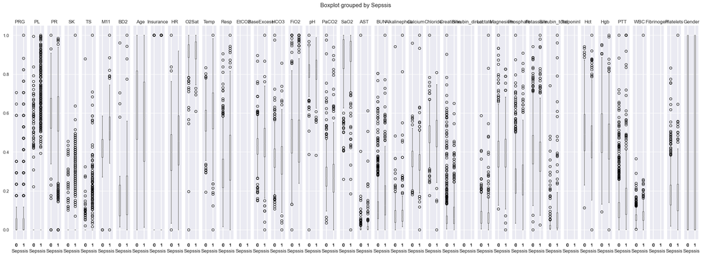

```python
candidates = columns[1:-1]
fig, ax = plt.subplots(figsize=(30, 10))
plot = df_scaled.boxplot(column=candidates,  by="Sepssis", layout=(1,40), ax=ax)
```

a lot of circles could represent outliers or extreme values in the dataset. is that the case here?

#### selecting features , after evaluating the BoxPlots and the Correlation HeatMap

```python
features = ["PL", "Age", "M11", "PR", "TS", "BD2", "HR", "Resp" , "BUN" , "PTT"]
target = "Sepssis"

X = df_scaled[features]
y = df_scaled[target]


from sklearn.model_selection import train_test_split
X_train, X_test, y_train, y_test = train_test_split(X, y, test_size=0.2)
print("There are in total", len(X), "observations, of which", len(X_train), "are now in the train set, and", len(X_test), "in the test set.")
```

```
There are in total 1762 observations, of which 1409 are now in the train set, and 353 in the test set.
```

## Reasoning

I added HartRate, Respiration rate, Blood urea nitrogen, partial thromboplastin time. I chose these features since they provided the most divivation in the box plots , as well as the hiest corelation to sepsis in the heatMap

#### taking a look for paterns in our selected features

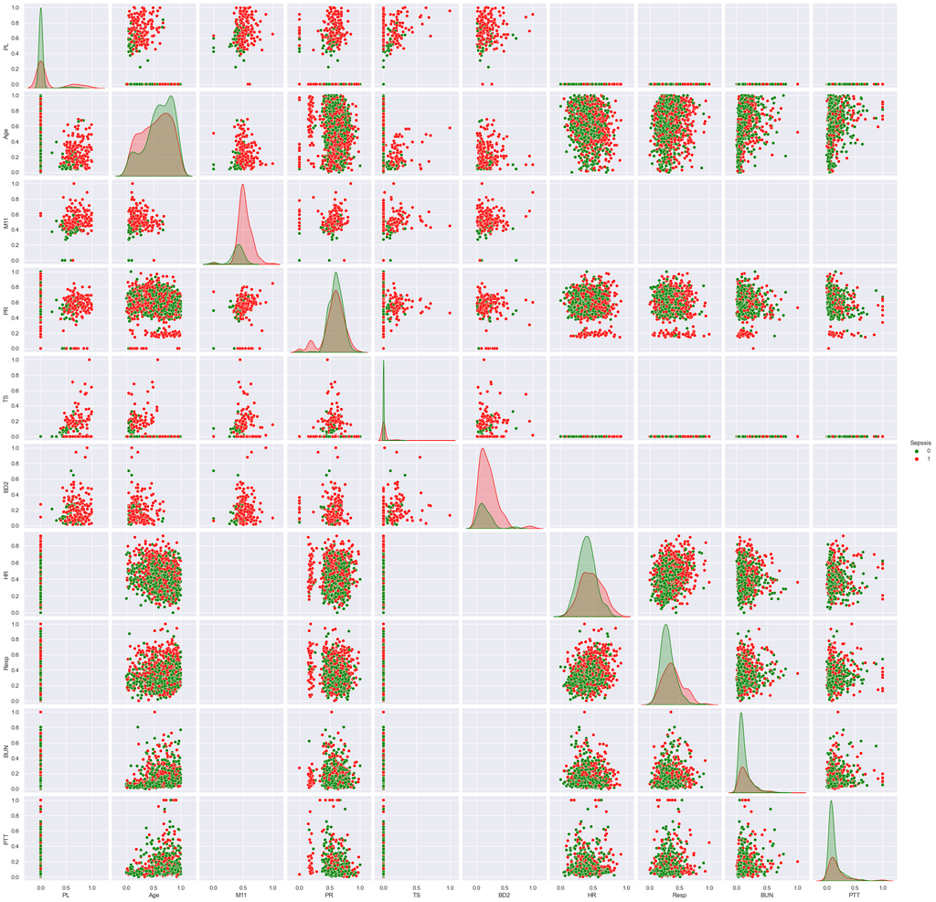

```python
train_df = pandas.concat([X_train, y_train], axis=1)
seaborn.set_theme()
cmap = {1: "red", 0: "green"}
seaborn.pairplot(train_df, hue=target, palette=cmap )
```

it is hard to see any patterns or coloration between the features, but we can see that there are some lines forming at 0.0 which is unavoidable since we have a lot of features who never meet each other on a same row (connection between them cant be made)

#### pushing the data to a model that supports NaN values

```python
from sklearn.experimental import enable_hist_gradient_boosting  # Required to use HistGradientBoostingClassifier
from sklearn.ensemble import HistGradientBoostingClassifier
from sklearn.metrics import accuracy_score, classification_report
from sklearn.model_selection import cross_val_score
import pandas as pd

# Create and fit HistGradientBoostingClassifier
clf = HistGradientBoostingClassifier()
clf.fit(X_train, y_train)

# Make predictions and calculate accuracy
y_pred = clf.predict(X_test)
acc = accuracy_score(y_test, y_pred)
print("Accuracy:", acc)

# Convert y_test and y_pred to pandas Series to ensure 1D arrays
y_test_series = pd.Series(y_test)
y_pred_series = pd.Series(y_pred)

# Convert class labels to strings before creating target_names
target_names = [str(label) for label in encoder.classes_]
print(classification_report(y_test_series, y_pred_series, target_names=target_names))

# Perform cross-validation and print results
cv_scores = cross_val_score(clf, X, y, cv=5)
print("Cross validation results:", cv_scores)
```

```
Accuracy: 0.7535410764872521
              precision    recall  f1-score   support

           0       0.72      0.77      0.74       164
           1       0.79      0.74      0.76       189

    accuracy                           0.75       353
   macro avg       0.75      0.75      0.75       353
weighted avg       0.76      0.75      0.75       353

Cross validation results: [0.80453258 0.7592068  0.72727273 0.75568182 0.69886364]
```

we can see that there wasn't a significant change in the performance of the model

##### what are the benefits:

we might not always have all the parameters available to us, but we might have difrent once, by broadening the the range of posible inputs of our model(and adding support for NaN values) we will increase the cases that the system can be used

##### detailed reasoning and explanation at the end of the notebook:

#### what if we use only the transformedAdditionDataset

```python
dff = pandas.read_csv("balancedCombinedDataset.csv", names=columns)
dff.drop(dff.index[:257], inplace=True)   # droping the old dataset

#dff = dff[dff['Sepssis'].notna()]
dff.reset_index(drop=True, inplace=True)


from sklearn.preprocessing import StandardScaler, MinMaxScaler

dff.drop(columns=["ID"], inplace=True)
from sklearn import preprocessing
encoder = preprocessing.LabelEncoder()
dff["Sepssis"] = encoder.fit_transform(dff["Sepssis"])

# Separate the target variable from the input features
X = dff.iloc[:,:-1]  # input features
y = dff.iloc[:, -1]  # target variable (sepsis)

# Scale the input features only\
#scaler = StandardScaler()
scaler = MinMaxScaler(feature_range=(0, 1))
scaler.fit(X)
X_scaled = scaler.transform(X)

# Combine the scaled input features and the target variable
df_scaled = pandas.concat([pandas.DataFrame(X_scaled, columns=X.columns), y], axis=1)


features = [ "Age", "PR",  "BD2", "HR", "Resp" , "BUN" , "PTT"]
target = "Sepssis"

X = df_scaled[features]
y = df_scaled[target]


from sklearn.model_selection import train_test_split
X_train, X_test, y_train, y_test = train_test_split(X, y, test_size=0.2)
print("There are in total", len(X), "observations, of which", len(X_train), "are now in the train set, and", len(X_test), "in the test set.")




from sklearn.ensemble import HistGradientBoostingClassifier
from sklearn.metrics import accuracy_score, classification_report
from sklearn.model_selection import cross_val_score
import pandas as pd



# Create and fit HistGradientBoostingClassifier
clf = HistGradientBoostingClassifier()
clf.fit(X_train, y_train)

# Make predictions and calculate accuracy
y_pred = clf.predict(X_test)
acc = accuracy_score(y_test, y_pred)
print("Accuracy:", acc)

# Convert y_test and y_pred to pandas Series to ensure 1D arrays
y_test_series = pd.Series(y_test)
y_pred_series = pd.Series(y_pred)

# Convert class labels to strings before creating target_names
target_names = [str(label) for label in encoder.classes_]
print(classification_report(y_test_series, y_pred_series, target_names=target_names))

# Perform cross-validation and print results
cv_scores = cross_val_score(clf, X, y, cv=5)
print("Cross validation results:", cv_scores)
```

```
There are in total 1505 observations, of which 1204 are now in the train set, and 301 in the test set.
```

```
Accuracy: 0.7375415282392026
              precision    recall  f1-score   support

           0       0.72      0.83      0.77       159
           1       0.77      0.63      0.69       142

    accuracy                           0.74       301
   macro avg       0.74      0.73      0.73       301
weighted avg       0.74      0.74      0.73       301

Cross validation results: [0.75083056 0.73089701 0.7641196  0.71428571 0.73421927]
```

#### evaluation of the original dataset for refrence (first dataset)

```
Accuracy:
              precision    recall  f1-score   support

    Negative       0.78      0.78      0.78        45
    Positive       0.74      0.74      0.74        38

    accuracy                           0.76        83
   macro avg       0.76      0.76      0.76        83
weighted avg       0.76      0.76      0.76        83

Cross validation results [0.74698795 0.71084337 0.69879518 0.75609756 0.76829268]
```

## Conclusion

Based on the evaluation results, it can be concluded that the performance of the combined dataset is relatively similar to the individual datasets in terms of accuracy, precision, recall, and F1-score.

##### based on this reasoning I will choose the combined dataset as it builds upon the first dataset and adds more features that gives medical professionals more flexibility in the use of the model